# Project: Investigate a Dataset (Replace this with something more specific!)

```python
#Check Duplicates values
sum(movies.duplicated())
```

```
1
```

```python
#droping Duplicates values
movies.drop_duplicates(inplace = True)
```

```python
#make sure there is Duplicates values
sum(movies.duplicated())
```

```
0
```

```python
#check missing values
movies.isnull().sum()
```

```
id                         0
popularity                 0
budget                     0
revenue                    0
original_title             0
cast                      76
director                  44
keywords                1493
overview                   4
runtime                    0
genres                    23
production_companies    1030
release_date               0
vote_count                 0
vote_average               0
release_year               0
budget_adj                 0
revenue_adj                0
dtype: int64
```

```python
#drop missing values
movies.dropna(how = 'any',inplace = True)
```

```python
#make sure there is no missing values
movies.isnull().sum()
```

```
id                      0
popularity              0
budget                  0
revenue                 0
original_title          0
cast                    0
director                0
keywords                0
overview                0
runtime                 0
genres                  0
production_companies    0
release_date            0
vote_count              0
vote_average            0
release_year            0
budget_adj              0
revenue_adj             0
dtype: int64
```

```python
movies.info()
```

```
<class 'pandas.core.frame.DataFrame'>
Int64Index: 8666 entries, 0 to 10865
Data columns (total 18 columns):
 #   Column                Non-Null Count  Dtype
---  ------                --------------  -----
 0   id                    8666 non-null   int64
 1   popularity            8666 non-null   float64
 2   budget                8666 non-null   int64
 3   revenue               8666 non-null   int64
 4   original_title        8666 non-null   object
 5   cast                  8666 non-null   object
 6   director              8666 non-null   object
 7   keywords              8666 non-null   object
 8   overview              8666 non-null   object
 9   runtime               8666 non-null   int64
 10  genres                8666 non-null   object
 11  production_companies  8666 non-null   object
 12  release_date          8666 non-null   object
 13  vote_count            8666 non-null   int64
 14  vote_average          8666 non-null   float64
 15  release_year          8666 non-null   int64
 16  budget_adj            8666 non-null   float64
 17  revenue_adj           8666 non-null   float64
dtypes: float64(4), int64(6), object(8)
memory usage: 1.3+ MB
```

```python
#fix datatypes
movies['release_date'] = pd.to_datetime(movies['release_date'])
```

```python
#check datatypes
movies.info()
```

```
<class 'pandas.core.frame.DataFrame'>
Int64Index: 8666 entries, 0 to 10865
Data columns (total 18 columns):
 #   Column                Non-Null Count  Dtype
---  ------                --------------  -----
 0   id                    8666 non-null   int64
 1   popularity            8666 non-null   float64
 2   budget                8666 non-null   int64
 3   revenue               8666 non-null   int64
 4   original_title        8666 non-null   object
 5   cast                  8666 non-null   object
 6   director              8666 non-null   object
 7   keywords              8666 non-null   object
 8   overview              8666 non-null   object
 9   runtime               8666 non-null   int64
 10  genres                8666 non-null   object
 11  production_companies  8666 non-null   object
 12  release_date          8666 non-null   datetime64[ns]
 13  vote_count            8666 non-null   int64
 14  vote_average          8666 non-null   float64
 15  release_year          8666 non-null   int64
 16  budget_adj            8666 non-null   float64
 17  revenue_adj           8666 non-null   float64
dtypes: datetime64[ns](1), float64(4), int64(6), object(7)
memory usage: 1.3+ MB
```

```python
#check zere runtime
movies[movies['runtime']==0].count()
```

```
id                      7
popularity              7
budget                  7
revenue                 7
original_title          7
cast                    7
director                7
keywords                7
overview                7
runtime                 7
genres                  7
production_companies    7
release_date            7
vote_count              7
vote_average            7
release_year            7
budget_adj              7
revenue_adj             7
dtype: int64
```

```python
#indexing zere runtime
movies[movies['runtime']==0]
```

|  | id | popularity | budget | revenue | original_title | cast | director | keywords | overview | runtime | genres | production_companies | release_date | vote_count | vote_average | release_year | budget_adj | revenue_adj |
| --- | --- | --- | --- | --- | --- | --- | --- | --- | --- | --- | --- | --- | --- | --- | --- | --- | --- | --- |
| 92 | 370687 | 1.876037 | 0 | 0 | Mythica: The Necromancer | Melanie Stone\|Adam Johnson\|Kevin Sorbo\|Nicola ... | A. Todd Smith | sword\|magic\|sorcery\|necromancer | Mallister takes Thane prisoner and forces Mare... | 0 | Fantasy\|Action\|Adventure | Arrowstorm Entertainment\|Camera 40 Productions... | 2015-12-19 | 11 | 5.4 | 2015 | 0.000000e+00 | 0.0 |
| 334 | 361931 | 0.357654 | 0 | 0 | Ronaldo | Cristiano Ronaldo | Anthony Wonke | biography\|soccer player | Filmed over 14 months with unprecedented acces... | 0 | Documentary | On The Corner Films\|We Came, We Saw, We Conque... | 2015-11-09 | 80 | 6.5 | 2015 | 0.000000e+00 | 0.0 |
| 486 | 333653 | 0.176744 | 0 | 0 | If There Be Thorns | Heather Graham\|Jason Lewis\|Rachael Carpani\|Mas... | Nancy Savoca | woman director | The third installment in V.C. Andrews’ bests... | 0 | TV Movie\|Drama | A+E Studios\|Jane Startz Productions | 2015-04-05 | 11 | 5.4 | 2015 | 0.000000e+00 | 0.0 |
| 1289 | 286372 | 0.037459 | 3250000 | 0 | Treehouse | J. Michael Trautmann\|Dana Melanie\|Daniel Fredr... | Michael G. Bartlett | kidnapping\|brutality\|violence\|teenager\|discovery | A teenage boy discovers the perpetrators of se... | 0 | Thriller\|Horror\|Mystery | Tiberius Film | 2014-10-20 | 16 | 3.4 | 2014 | 2.993546e+06 | 0.0 |
| 1293 | 286256 | 0.036904 | 0 | 0 | Tim Maia | Robson Nunes\|Babú Santana\|Alinne Moraes\|Cauã... | Mauro Lima | brazilian\|biography\|music\|drama\|documentary | Biopic of Brazilian singer Tim Maia, from his ... | 0 | Documentary\|Drama\|Music | Globo Filmes | 2014-10-30 | 14 | 6.0 | 2014 | 0.000000e+00 | 0.0 |
| 5920 | 248842 | 0.165765 | 0 | 0 | The Food Guide to Love | Richard Coyle\|Leonor Watling\|Ginés García Mi... | Dominic Harari\|Teresa Pelegri | woman director | A dysfunctional love story about an Irish food... | 0 | Romance\|Comedy | Haut et Court\|Parallel Film Productions\|Fox In... | 2013-12-18 | 12 | 5.6 | 2013 | 0.000000e+00 | 0.0 |
| 5938 | 191562 | 0.147188 | 0 | 0 | Go Goa Gone | Saif Ali Khan\|Anand Tiwari\|Vir Das\|Pooja Gupta | Krishna D.K.\|Raj Nidimoru | hindi\|zombies island\|zombies\|zombie survival | A rave party off the coast of Goa, goes horrif... | 0 | Comedy\|Horror | Eros International | 2013-05-10 | 16 | 5.3 | 2013 | 0.000000e+00 | 0.0 |

```python
#indexing zere runtime
movies=movies.drop([92,334,486,1289,1293,5920,5938])
```

```python
#check zere runtime
movies[movies['runtime']==0].count()
```

```
id                      0
popularity              0
budget                  0
revenue                 0
original_title          0
cast                    0
director                0
keywords                0
overview                0
runtime                 0
genres                  0
production_companies    0
release_date            0
vote_count              0
vote_average            0
release_year            0
budget_adj              0
revenue_adj             0
dtype: int64
```

```python
movies.info()
```

```
<class 'pandas.core.frame.DataFrame'>
Int64Index: 8659 entries, 0 to 10865
Data columns (total 18 columns):
 #   Column                Non-Null Count  Dtype
---  ------                --------------  -----
 0   id                    8659 non-null   int64
 1   popularity            8659 non-null   float64
 2   budget                8659 non-null   int64
 3   revenue               8659 non-null   int64
 4   original_title        8659 non-null   object
 5   cast                  8659 non-null   object
 6   director              8659 non-null   object
 7   keywords              8659 non-null   object
 8   overview              8659 non-null   object
 9   runtime               8659 non-null   int64
 10  genres                8659 non-null   object
 11  production_companies  8659 non-null   object
 12  release_date          8659 non-null   datetime64[ns]
 13  vote_count            8659 non-null   int64
 14  vote_average          8659 non-null   float64
 15  release_year          8659 non-null   int64
 16  budget_adj            8659 non-null   float64
 17  revenue_adj           8659 non-null   float64
dtypes: datetime64[ns](1), float64(4), int64(6), object(7)
memory usage: 1.3+ MB
```

```python
#columns (cast , keywords, genres , production_companies) contains "|"
#split data beween '|'

split_columns = ['cast', 'keywords', 'genres', 'production_companies']
for x in split_columns:
        c_name=x
        x=movies[x].str[0:].str.split('|',expand = True)
        x['id']=movies['id']
        pd.melt(x,id_vars = 'id',value_name=c_name).drop(labels = 'variable',axis = 1)
        x.dropna(inplace = True)
```

```python
#droping columns that containes '|'
movies=movies.drop(columns=['cast', 'keywords', 'genres', 'production_companies'],axis = 1)
```

```python
movies
```

|  | id | popularity | budget | revenue | original_title | director | overview | runtime | release_date | vote_count | vote_average | release_year | budget_adj | revenue_adj |
| --- | --- | --- | --- | --- | --- | --- | --- | --- | --- | --- | --- | --- | --- | --- |
| 0 | 135397 | 32.985763 | 150000000 | 1513528810 | Jurassic World | Colin Trevorrow | Twenty-two years after the events of Jurassic ... | 124 | 2015-06-09 | 5562 | 6.5 | 2015 | 1.379999e+08 | 1.392446e+09 |
| 1 | 76341 | 28.419936 | 150000000 | 378436354 | Mad Max: Fury Road | George Miller | An apocalyptic story set in the furthest reach... | 120 | 2015-05-13 | 6185 | 7.1 | 2015 | 1.379999e+08 | 3.481613e+08 |
| 2 | 262500 | 13.112507 | 110000000 | 295238201 | Insurgent | Robert Schwentke | Beatrice Prior must confront her inner demons ... | 119 | 2015-03-18 | 2480 | 6.3 | 2015 | 1.012000e+08 | 2.716190e+08 |
| 3 | 140607 | 11.173104 | 200000000 | 2068178225 | Star Wars: The Force Awakens | J.J. Abrams | Thirty years after defeating the Galactic Empi... | 136 | 2015-12-15 | 5292 | 7.5 | 2015 | 1.839999e+08 | 1.902723e+09 |
| 4 | 168259 | 9.335014 | 190000000 | 1506249360 | Furious 7 | James Wan | Deckard Shaw seeks revenge against Dominic Tor... | 137 | 2015-04-01 | 2947 | 7.3 | 2015 | 1.747999e+08 | 1.385749e+09 |
| ... | ... | ... | ... | ... | ... | ... | ... | ... | ... | ... | ... | ... | ... | ... |
| 10861 | 21 | 0.080598 | 0 | 0 | The Endless Summer | Bruce Brown | The Endless Summer, by Bruce Brown, is one of ... | 95 | 2066-06-15 | 11 | 7.4 | 1966 | 0.000000e+00 | 0.000000e+00 |
| 10862 | 20379 | 0.065543 | 0 | 0 | Grand Prix | John Frankenheimer | Grand Prix driver Pete Aron is fired by his te... | 176 | 2066-12-21 | 20 | 5.7 | 1966 | 0.000000e+00 | 0.000000e+00 |
| 10863 | 39768 | 0.065141 | 0 | 0 | Beregis Avtomobilya | Eldar Ryazanov | An insurance agent who moonlights as a carthie... | 94 | 2066-01-01 | 11 | 6.5 | 1966 | 0.000000e+00 | 0.000000e+00 |
| 10864 | 21449 | 0.064317 | 0 | 0 | What's Up, Tiger Lily? | Woody Allen | In comic Woody Allen's film debut, he took the... | 80 | 2066-11-02 | 22 | 5.4 | 1966 | 0.000000e+00 | 0.000000e+00 |
| 10865 | 22293 | 0.035919 | 19000 | 0 | Manos: The Hands of Fate | Harold P. Warren | A family gets lost on the road and stumbles up... | 74 | 2066-11-15 | 15 | 1.5 | 1966 | 1.276423e+05 | 0.000000e+00 |

8659 rows × 14 columns

```python
#check duplicated in ['cast', 'keywords', 'genres', 'production_companies']

print(sum(cast.duplicated()))
print(sum(keywords.duplicated()))
print(sum(genres.duplicated()))
print(sum(production_companies.duplicated()))
```

```
0
0
0
0
```

```python
#droping duplicates values in ['cast','production_companies']

cast.drop_duplicates(inplace = True) , production_companies.drop_duplicates(inplace = True)
```

```
(None, None)
```

```python
#check missing values in ['cast','production_companies']

print(cast.isnull().sum())
print(keywords.isnull().sum())
print(genres.isnull().sum())
print(production_companies.isnull().sum())
```

```
id      0
cast    0
dtype: int64
id          0
keywords    0
dtype: int64
id        0
genres    0
dtype: int64
id                      0
production_companies    0
dtype: int64
```

```python
movies.info()
```

```
<class 'pandas.core.frame.DataFrame'>
Int64Index: 8659 entries, 0 to 10865
Data columns (total 14 columns):
 #   Column          Non-Null Count  Dtype
---  ------          --------------  -----
 0   id              8659 non-null   int64
 1   popularity      8659 non-null   float64
 2   budget          8659 non-null   int64
 3   revenue         8659 non-null   int64
 4   original_title  8659 non-null   object
 5   director        8659 non-null   object
 6   overview        8659 non-null   object
 7   runtime         8659 non-null   int64
 8   release_date    8659 non-null   datetime64[ns]
 9   vote_count      8659 non-null   int64
 10  vote_average    8659 non-null   float64
 11  release_year    8659 non-null   int64
 12  budget_adj      8659 non-null   float64
 13  revenue_adj     8659 non-null   float64
dtypes: datetime64[ns](1), float64(4), int64(6), object(3)
memory usage: 1014.7+ KB
```

## Exploratory Data Analysis

> **Tip**: Now that you've trimmed and cleaned your data, you're ready to move on to exploration. Compute statistics and create visualizations with the goal of addressing the research questions that you posed in the Introduction section. It is recommended that you be systematic with your approach. Look at one variable at a time, and then follow it up by looking at relationships between variables.

### Research Question 1 (which genres of movies are most ?)

```python
genres_values=genres['genres'].value_counts()
genres_values
```

```
Drama              3932
Comedy             3048
Thriller           2461
Action             2021
Romance            1414
Horror             1337
Adventure          1270
Crime              1200
Science Fiction    1028
Family              946
Fantasy             762
Mystery             702
Animation           512
Music               308
History             287
Documentary         268
War                 235
Western             154
TV Movie            114
Foreign              90
Name: genres, dtype: int64
```

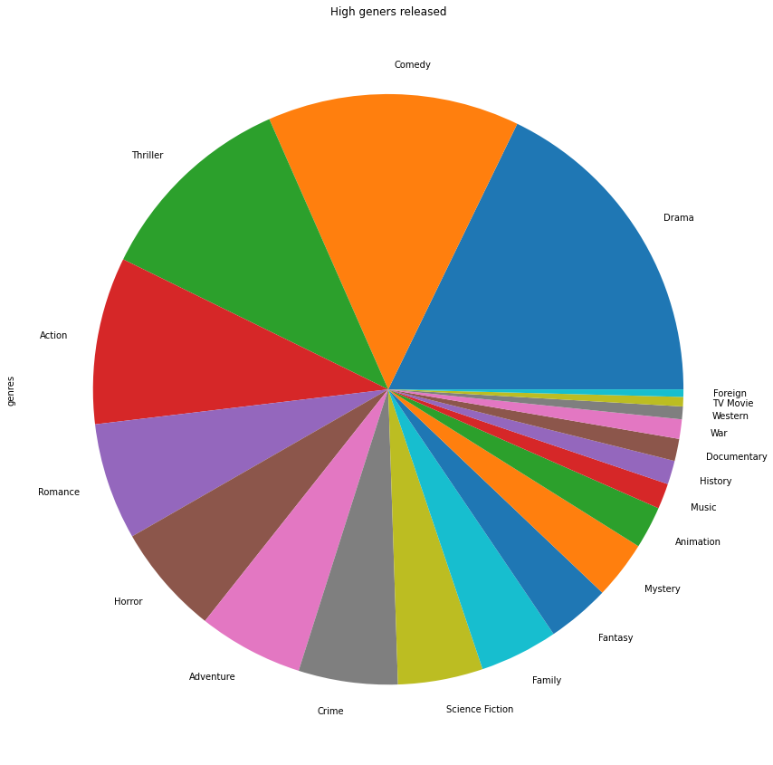

```python
# Use this, and more code cells, to explore your data. Don't forget to add
#   Markdown cells to document your observations and findings.

genres_values.plot(x=genres_values.index,y=genres_values,kind='pie',figsize=(25,15));
plt.title('High geners released');
```

### It showes that Dram,Comedy,Thriller,Action are the most realsed

### Research Question 2 (what is the year that released highest number of movies ?)

```python
movies['release_year'].value_counts().reset_index().sort_values(by = 'index')
```

|  | index | release_year |
| --- | --- | --- |
| 53 | 1960 | 30 |
| 54 | 1961 | 28 |
| 52 | 1962 | 30 |
| 50 | 1963 | 33 |
| 44 | 1964 | 41 |
| 51 | 1965 | 33 |
| 42 | 1966 | 44 |
| 49 | 1967 | 34 |
| 47 | 1968 | 36 |
| 55 | 1969 | 25 |
| 46 | 1970 | 38 |
| 39 | 1971 | 54 |
| 48 | 1972 | 36 |
| 37 | 1973 | 55 |
| 43 | 1974 | 43 |
| 45 | 1975 | 40 |
| 41 | 1976 | 44 |
| 40 | 1977 | 54 |
| 36 | 1978 | 59 |
| 38 | 1979 | 54 |
| 35 | 1980 | 72 |
| 33 | 1981 | 74 |
| 32 | 1982 | 78 |
| 34 | 1983 | 74 |
| 31 | 1984 | 96 |
| 30 | 1985 | 96 |
| 29 | 1986 | 103 |
| 28 | 1987 | 104 |
| 25 | 1988 | 120 |
| 26 | 1989 | 118 |
| 23 | 1990 | 123 |
| 27 | 1991 | 111 |
| 24 | 1992 | 120 |
| 20 | 1993 | 165 |
| 21 | 1994 | 164 |
| 22 | 1995 | 159 |
| 17 | 1996 | 182 |
| 19 | 1997 | 174 |
| 18 | 1998 | 181 |
| 14 | 1999 | 198 |
| 16 | 2000 | 184 |
| 15 | 2001 | 196 |
| 12 | 2002 | 219 |
| 13 | 2003 | 214 |
| 11 | 2004 | 237 |
| 10 | 2005 | 299 |
| 9 | 2006 | 325 |
| 7 | 2007 | 347 |
| 6 | 2008 | 380 |
| 3 | 2009 | 413 |
| 8 | 2010 | 343 |
| 5 | 2011 | 383 |
| 4 | 2012 | 387 |
| 1 | 2013 | 454 |
| 0 | 2014 | 518 |
| 2 | 2015 | 437 |

```python
movies['release_year'].value_counts().reset_index().max()
```

```
index           2015
release_year     518
dtype: int64
```

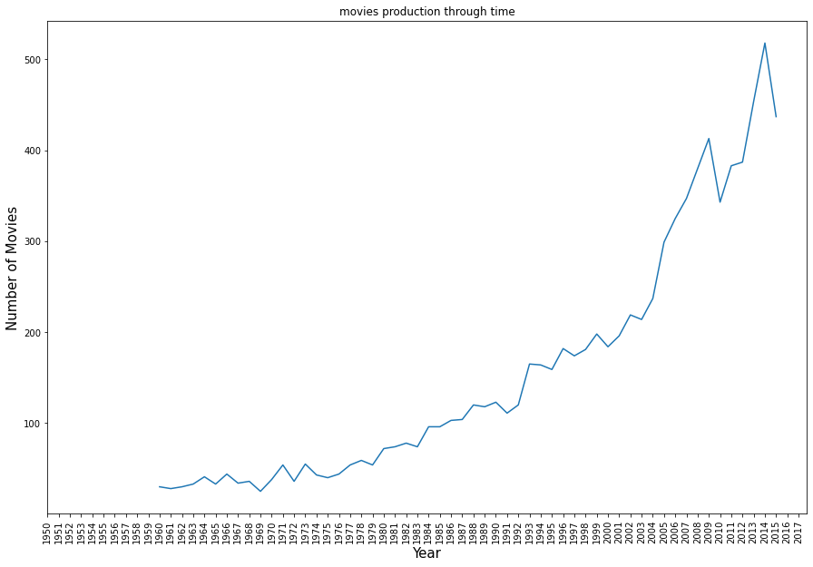

```python
# Continue to explore the data to address your additional research
#   questions. Add more headers as needed if you have more questions to
#   investigate.

plt.figure(figsize = (15,10));
x = movies['release_year'].value_counts().reset_index().sort_values(by = 'index')
plt.plot(x['index'],x['release_year']);
plt.xticks(np.arange(1950,2018,1),rotation = 90);
plt.xlabel('Year',fontsize = 15);
plt.ylabel('Number of Movies', fontsize  =15)
plt.title('movies production through time');
```

### There is increasing in movies production through years

### Research Question 3 (What are the most popular genres ?)

```python
movies_geners = pd.merge(movies,genres,on  = 'id')
movies_geners.drop(columns=['budget', 'revenue', 'original_title', 'director',
       'overview', 'release_date', 'vote_count', 'vote_average',
       'release_year', 'budget_adj', 'revenue_adj'])
```

|  | id | popularity | runtime | genres |
| --- | --- | --- | --- | --- |
| 0 | 135397 | 32.985763 | 124 | Action |
| 1 | 135397 | 32.985763 | 124 | Adventure |
| 2 | 135397 | 32.985763 | 124 | Science Fiction |
| 3 | 135397 | 32.985763 | 124 | Thriller |
| 4 | 76341 | 28.419936 | 120 | Action |
| ... | ... | ... | ... | ... |
| 22084 | 39768 | 0.065141 | 94 | Mystery |
| 22085 | 39768 | 0.065141 | 94 | Comedy |
| 22086 | 21449 | 0.064317 | 80 | Action |
| 22087 | 21449 | 0.064317 | 80 | Comedy |
| 22088 | 22293 | 0.035919 | 74 | Horror |

22089 rows × 4 columns

```python
movies_geners['popularity'].max()
```

```
32.985763
```

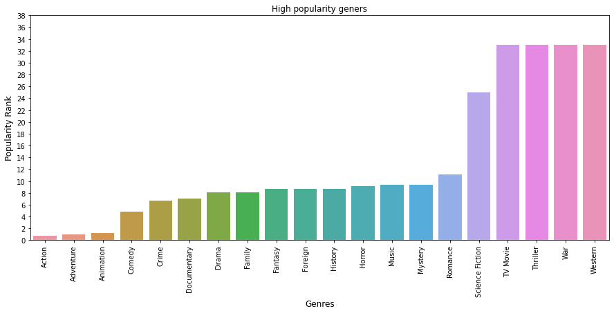

```python
plt.figure(figsize = (15,6));
sns.barplot(x = movies_geners.groupby('genres').max()['popularity'].index,
            y = movies_geners.groupby('genres').max()['popularity'].sort_values(ascending = True));
plt.xlabel('Genres', fontsize = 12);
plt.ylabel('Popularity Rank', fontsize = 12);
plt.xticks(rotation = 90);
plt.yticks(np.arange(0,40,2))
plt.title('High popularity geners');
```

### Research Question 4 (which is the most Runtime of geners ?)

```python
movies['runtime'].max()
```

```
705
```

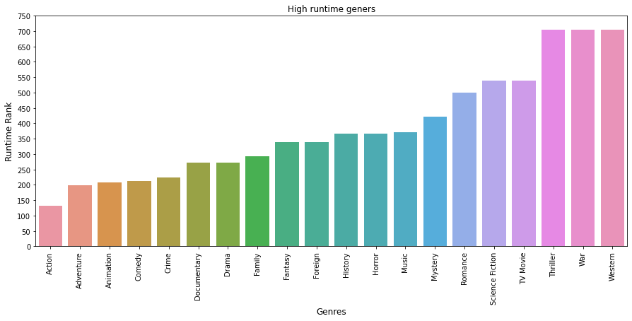

```python
plt.figure(figsize = (15,6));
sns.barplot(x = movies_geners.groupby('genres').max()['runtime'].index,
            y = movies_geners.groupby('genres').max()['runtime'].sort_values(ascending = True));
plt.xlabel('Genres', fontsize = 12);
plt.ylabel('Runtime Rank', fontsize = 12);
plt.xticks(rotation = 90);
plt.yticks(np.arange(0,800,50))
plt.title('High runtime geners');
```

### Research Question 5 (Are genres that have the most revenue is the most populartity?)

```python
movies[movies['revenue']==movies['revenue'].max()]
```

|  | id | popularity | budget | revenue | original_title | director | overview | runtime | release_date | vote_count | vote_average | release_year | budget_adj | revenue_adj |
| --- | --- | --- | --- | --- | --- | --- | --- | --- | --- | --- | --- | --- | --- | --- |
| 1386 | 19995 | 9.432768 | 237000000 | 2781505847 | Avatar | James Cameron | In the 22nd century, a paraplegic Marine is di... | 162 | 2009-12-10 | 8458 | 7.1 | 2009 | 2.408869e+08 | 2.827124e+09 |

```python
movies['revenue'].sort_values(ascending = False)[:5]
```

```
1386    2781505847
3       2068178225
5231    1845034188
4361    1519557910
0       1513528810
Name: revenue, dtype: int64
```

```python
movies['popularity'].mean()
```

```
0.7422133602032557
```

```python
movies.groupby('popularity').max()['revenue'].sort_values(ascending = False).reset_index()
```

|  | popularity | revenue |
| --- | --- | --- |
| 0 | 9.432768 | 2781505847 |
| 1 | 11.173104 | 2068178225 |
| 2 | 4.355219 | 1845034188 |
| 3 | 7.637767 | 1519557910 |
| 4 | 32.985763 | 1513528810 |
| ... | ... | ... |
| 8629 | 0.363695 | 0 |
| 8630 | 0.363730 | 0 |
| 8631 | 0.363923 | 0 |
| 8632 | 0.363927 | 0 |
| 8633 | 0.000188 | 0 |

8634 rows × 2 columns

[figure not shown]

```python
plt.figure(figsize = (15,6));
sns.barplot(x = movies_geners.groupby('genres').max()['revenue'].index,
            y = movies_geners.groupby('genres').max()['revenue'].sort_values(ascending = True));
plt.xlabel('Genres', fontsize = 12);
plt.ylabel('Revenue Rank', fontsize = 12);
plt.xticks(rotation = 90);
plt.yticks(np.arange(0,800,50))
plt.title('High revenue geners');
```